# wilcox test

```r
wilcox.test(diet, diet.bone)
```

```
##
##  Wilcoxon rank sum test with continuity correction
##
## data:  diet and diet.bone
## W = 63.5, p-value = 0.0374
## alternative hypothesis: true location shift is not equal to 0
```

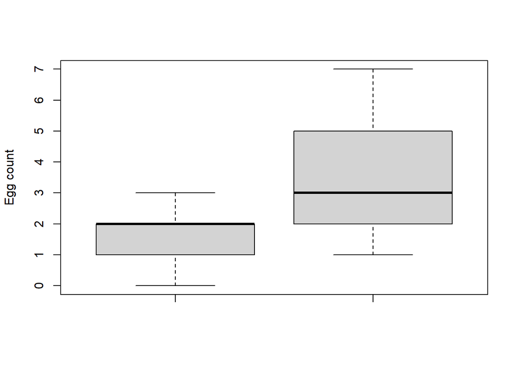

```r
boxplot(diet, diet.bone, ylab = 'Egg count')
```

# Result

We found evidence of a difference in the number of eggs laid under a control diet and a a diet supplemeted with bone meal.

## Linear regression

dataset source:https://www.kaggle.com/datasets/aungpyaeap/fish market

```r
library(readxl) #load library
setwd ("C:/Users/DELL/Downloads") #set working directory
fish <- read_excel("fish.xlsx")
names(fish)
```

```
## [1] "Species" "Weight"  "Length1" "Length2" "Length3" "Height"  "Width"
```

```r
table(fish$Species)
```

```
##
##     Bream    Parkki     Perch      Pike     Roach     Smelt Whitefish
##        35        11        56        17        20        14         6
```

# slice out the rows of perch

```r
fish$Species =="Perch"
```

```
##   [1] FALSE FALSE FALSE FALSE FALSE FALSE FALSE FALSE FALSE FALSE FALSE FALSE
##  [13] FALSE FALSE FALSE FALSE FALSE FALSE FALSE FALSE FALSE FALSE FALSE FALSE
##  [25] FALSE FALSE FALSE FALSE FALSE FALSE FALSE FALSE FALSE FALSE FALSE FALSE
##  [37] FALSE FALSE FALSE FALSE FALSE FALSE FALSE FALSE FALSE FALSE FALSE FALSE
##  [49] FALSE FALSE FALSE FALSE FALSE FALSE FALSE FALSE FALSE FALSE FALSE FALSE
##  [61] FALSE FALSE FALSE FALSE FALSE FALSE FALSE FALSE FALSE FALSE FALSE FALSE
##  [73]  TRUE  TRUE  TRUE  TRUE  TRUE  TRUE  TRUE  TRUE  TRUE  TRUE  TRUE  TRUE
##  [85]  TRUE  TRUE  TRUE  TRUE  TRUE  TRUE  TRUE  TRUE  TRUE  TRUE  TRUE  TRUE
##  [97]  TRUE  TRUE  TRUE  TRUE  TRUE  TRUE  TRUE  TRUE  TRUE  TRUE  TRUE  TRUE
## [109]  TRUE  TRUE  TRUE  TRUE  TRUE  TRUE  TRUE  TRUE  TRUE  TRUE  TRUE  TRUE
## [121]  TRUE  TRUE  TRUE  TRUE  TRUE  TRUE  TRUE  TRUE FALSE FALSE FALSE FALSE
## [133] FALSE FALSE FALSE FALSE FALSE FALSE FALSE FALSE FALSE FALSE FALSE FALSE
## [145] FALSE FALSE FALSE FALSE FALSE FALSE FALSE FALSE FALSE FALSE FALSE FALSE
## [157] FALSE FALSE FALSE
```

```r
perch <- fish[fish$Species=="Perch" , ]
perch
```

```
## # A tibble: 56 × 7
##    Species Weight Length1 Length2 Length3 Height Width
##    <chr>    <dbl>   <dbl>   <dbl>   <dbl>  <dbl> <dbl>
##  1 Perch      5.9     7.5     8.4     8.8   2.11  1.41
##  2 Perch     32      12.5    13.7    14.7   3.53  2.00
##  3 Perch     40      13.8    15      16     3.82  2.43
##  4 Perch     51.5    15      16.2    17.2   4.59  2.63
##  5 Perch     70      15.7    17.4    18.5   4.59  2.94
##  6 Perch    100      16.2    18      19.2   5.22  3.32
##  7 Perch     78      16.8    18.7    19.4   5.20  3.12
##  8 Perch     80      17.2    19      20.2   5.64  3.05
##  9 Perch     85      17.8    19.6    20.8   5.14  3.04
## 10 Perch     85      18.2    20      21     5.08  2.77
## # … with 46 more rows
```

find the linear relationship between height and width of the perch species.

#make a plot

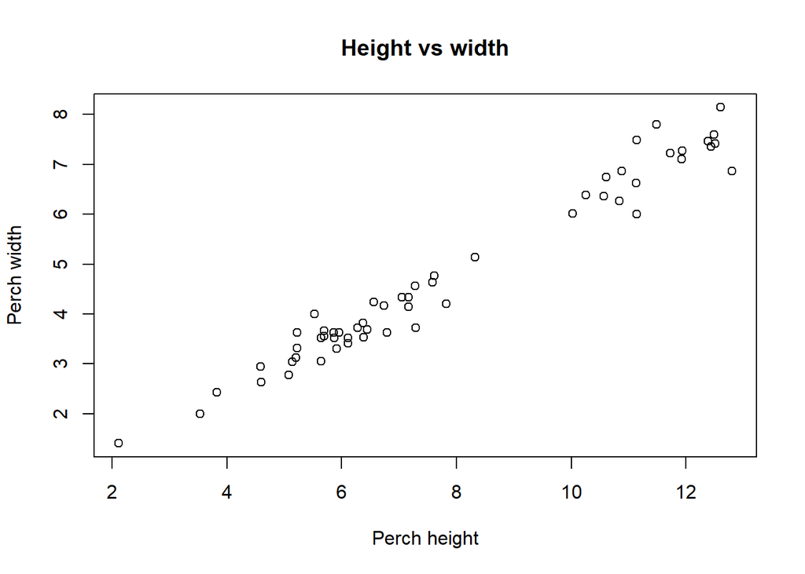

```r
plot(perch$Height, perch$Width,
     xlab = "Perch height",
     ylab = "Perch width",
     main = "Height vs width")
```

# make regression

```r
mylm <- lm(formula = Width ~ Height, data = perch)
mylm
```

```
##
## Call:
## lm(formula = Width ~ Height, data = perch)
##
## Coefficients:
## (Intercept)       Height
##    -0.01907      0.60606
```

#Test our assumption

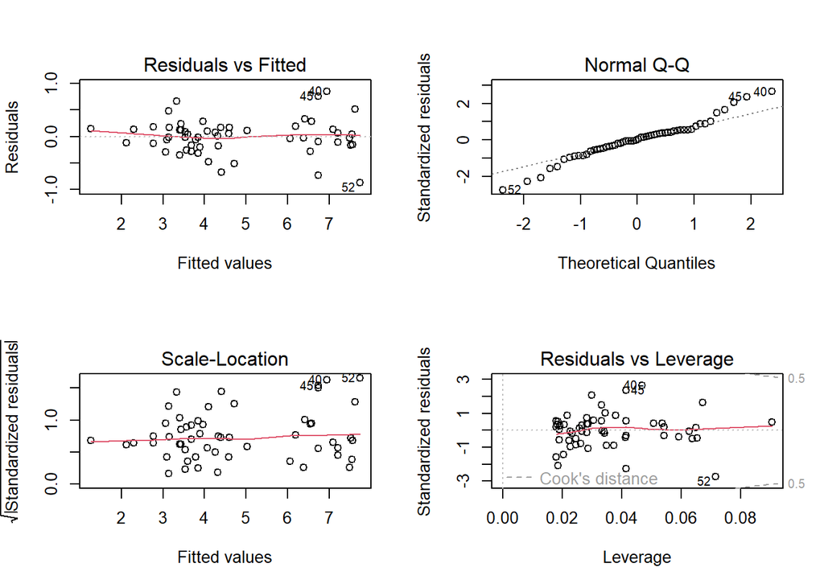

```r
par(mfrow = c(2,2))
plot(mylm)
```

```r
par(mfrow = c(1,1))
```

# perform shapiro test for normality

```r
shapiro.test(residuals(mylm))
```

```
##
##  Shapiro-Wilk normality test
##
## data:  residuals(mylm)
## W = 0.96567, p-value = 0.1111
```

p- value is more than significance level we can accept null hypothesis which means our data meets the normality.

# predictions

```r
prediction <- predict(mylm, interval = "confidence")
prediction
```

```
##         fit      lwr      upr
## 1  1.260939 1.062368 1.459509
## 2  2.119124 1.958613 2.279636
## 3  2.298519 2.145574 2.451464
## 4  2.764218 2.629987 2.898449
## 5  2.761551 2.627217 2.895885
## 6  3.146038 3.025809 3.266267
## 7  3.131977 3.011259 3.252695
## 8  3.396584 3.284647 3.508521
## 9  3.094644 2.972617 3.216670
## 10 3.060946 2.937726 3.184167
## 11 3.430948 3.320082 3.541814
## 12 3.567312 3.460516 3.674109
## 13 3.430948 3.320082 3.541814
## 14 3.850041 3.750655 3.949426
```

[output cut: 42 more lines]

# Result

```r
summary(mylm)
```

```
##
## Call:
## lm(formula = Width ~ Height, data = perch)
##
## Residuals:
##      Min       1Q   Median       3Q      Max
## -0.87026 -0.16016  0.00086  0.15315  0.85207
##
## Coefficients:
##             Estimate Std. Error t value Pr(>|t|)
## (Intercept) -0.01907    0.12905  -0.148    0.883
## Height       0.60606    0.01543  39.276   <2e-16 ***
## ---
## Signif. codes:  0 '***' 0.001 '**' 0.01 '*' 0.05 '.' 0.1 ' ' 1
##
## Residual standard error: 0.3294 on 54 degrees of freedom
## Multiple R-squared:  0.9662, Adjusted R-squared:  0.9656
## F-statistic:  1543 on 1 and 54 DF,  p-value: < 2.2e-16
```

we found significant evidance that linear relationship between height predictingwidth of the fish.for each centimeter increase in height will result in increase in width of the fish in centimeter.the multiple r squared is very import that is 96% which is high for our model that is variation in perch width is explained my perch height.